# STA 141A Final Project

Satoshi Shinkawa

2023-06-01

## 0.2 Background

Regarding the data, the experiment conducted on the mice was done with dates kept as records and done over time. The location of the brain and it’s neurons are observed using probes and the responses to stimuli are recorded as described in the introduction. The stimuli exposed to the mice was visual stimuli in which the mice would turn it’s wheel in response to it. The stimuli would either be admitted to its left side, right side, both sides, or not at all in which if a mouse responded in a correct manner, it would be rewarded with water. The target population of this project is the true coefficients that can help determine a correct response. The sampling mechanism used throughout the project is the built in sampling function provided by R-Studio to help easily gather samples from our main data. Machine learning can be used to attempt to predict with a model far superior to any model this project is capable of producing. Machine learning uses Functional Magnetic Resonance imaging (FMRi) data and stimulus as inputs in training predictive models. This can lead to making predictions about new, less obvious features of brain response patterns. If you would like to know more about this interesting topic, here are some resources: - Article: “Predicting the Brain Activation Pattern Associated with the Propositional Content of a Sentence: Modeling Neural Representations of Events and States” by Mitchell TM, Shinkareva SV, et al. (2008). - Book: “Machine Learning in Neuroscience” by Stephen José Hanson and Sjöström P. Jesper. - Article: “Deep Neural Networks Reveal a Gradient in the Complexity of Neural Representations across the Ventral Stream” by Yamins DL, Hong H, et al. (2014).

## 0.3 Descriptive analysis

The descriptive analysis provides basic univariate descriptive statistics for relevant variables (mean, standard deviations, missing values, quantiles, etc.), and a few multivariate description of key variables. Readers that are familiar with this topic or statistics gain basic insights of this data set, e.g., being able to generate hypotheses, spot abnormality (or the lack of), propose statistical models, evaluate the plausibility of assumptions.

In this part, the main task is to address questions in Part one.

Part 1 (15 points). Exploratory data analysis. In this part, we will explore the features of the data sets in order to build our prediction model. In particular, we would like to (i) describe the data structures across sessions (e.g., number of neurons, number of trials, stimuli conditions, feedback types), (ii) explore the neural activities during each trial, (iii) explore the changes across trials, and (iv) explore homogeneity and heterogeneity across sessions and mice.

**Grading criteria:** **To address (i), it would be best to use a table. Remember to explain what each variable represents.** **For (ii), (iii), and (iv), at least one figure should be included for each. Ensure that the x-axis and y-axis are clearly labeled, and provide an appropriate caption for each figure and table.** **Also, make sure to number them clearly for easy reference.** **Make sure you answered all questions in Part one. I hope you can answer those questions in order, but it’s not requuied.** **Lastly, it’s important to explain why you included those plots and how they address the questions in Part 1. This will help readers understand the significance of the data presented and how it contributes to the overall findings of the project.**

I will give you an example for problem 1.

The data for this project consists of eighteen sessions involving four different mice. The variables utilized in the project include `mouse_name` (the name of the mouse for specific sessions), `date_exp` (the date of the experiment), `n_brain_area` (the unique brain area involved), `n_neurons` (the number of neurons), `n_trials` (the number of trials in each session), and `success_rate` (the ratio of successful trials to the total number of trials). It is important to note that the selected data does not contain any missing values (**Table 1**).

```r
setwd("C:/Users/ultim/Downloads/STA 141A/sessions")
session=list()
for(i in 1:18){
  session[[i]]=readRDS(paste('session',i,'.rds',sep=''))
}
sessions <- session
```

| mouse_name | date_exp | n_brain_area | n_neurons | n_trials | success_rate |
| --- | --- | --- | --- | --- | --- |
| Cori | 2016-12-14 | 8 | 734 | 114 | 0.61 |
| Cori | 2016-12-17 | 5 | 1070 | 251 | 0.63 |
| Cori | 2016-12-18 | 11 | 619 | 228 | 0.66 |
| Forssmann | 2017-11-01 | 11 | 1769 | 249 | 0.67 |
| Forssmann | 2017-11-02 | 10 | 1077 | 254 | 0.66 |
| Forssmann | 2017-11-04 | 5 | 1169 | 290 | 0.74 |
| Forssmann | 2017-11-05 | 8 | 584 | 252 | 0.67 |
| Hench | 2017-06-15 | 15 | 1157 | 250 | 0.64 |
| Hench | 2017-06-16 | 12 | 788 | 372 | 0.69 |
| Hench | 2017-06-17 | 13 | 1172 | 447 | 0.62 |
| Hench | 2017-06-18 | 6 | 857 | 342 | 0.80 |
| Lederberg | 2017-12-05 | 12 | 698 | 340 | 0.74 |
| Lederberg | 2017-12-06 | 15 | 983 | 300 | 0.80 |
| Lederberg | 2017-12-07 | 10 | 756 | 268 | 0.69 |
| Lederberg | 2017-12-08 | 8 | 743 | 404 | 0.76 |
| Lederberg | 2017-12-09 | 6 | 474 | 280 | 0.72 |
| Lederberg | 2017-12-10 | 6 | 565 | 224 | 0.83 |
| Lederberg | 2017-12-11 | 10 | 1090 | 216 | 0.81 |

**Table 1**. Data structure across sessions.

> > This table splendidly displays the name of the mouse used in which session, the date the the experiment was conducted, and the number of brain areas used in a given session. In addition to this, the number of neurons recorded in each session, the number of trials in each session, and the overall success rate in which the mice are able to correctly respond to a stimulus. The information gathered from this table is incredibly helpful with summarizing what the very large and complicated sessions data set is composed of.

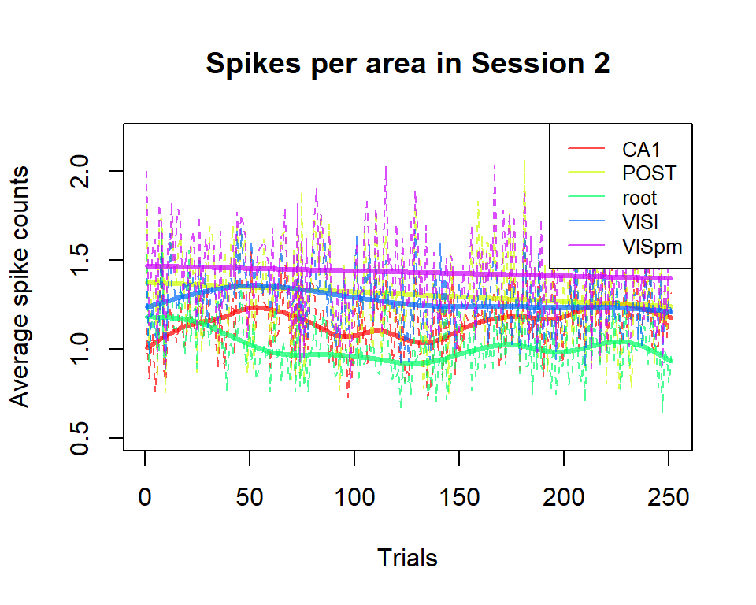

**Figure 1**. Average spike count across trials in session 2.

> > This plot is helpful because it is able to show the average of each brain area in a given session changes alongside it’s mean. We can observe spikes over trials in association with time grouped by brain area using this plot. We can also see that the VISpm brain area, for example, is the brain area with the highest average over all the trials. This is meaningful because this can perhaps indicate that if this brain area has a large amount of spikes, this could further determine whether the feedback type will be successful.

```r
#Function to help compare the unique brain areas to where
compare.brain.areas <- function(vector1,vector2){
  comparison <- vector1 %in% vector2
  return(any(comparison))
}
#Want to show which brain area is used what session
unique.brain.area.len <-length(name.brain.areas)
brain.area.per.session <- matrix(, nrow = n.session, ncol =unique.brain.area.len)
colnames(brain.area.per.session) <- name.brain.areas
rownames(brain.area.per.session) <- c(1:18)

#Want to compare what the unique names to all the brain ares
for(i in 1:n.session){
  tempVal <- c(session[[i]]$brain_area)
  for(j in 1:unique.brain.area.len){
    brain.area.per.session[i,j] = compare.brain.areas(tempVal,name.brain.areas[j])
  }
}
head(brain.area.per.session)
```

```
##     ACA   MOs    LS  root  VISp   CA3   SUB    DG   CA1  VISl VISpm  POST VISam
## 1  TRUE  TRUE  TRUE  TRUE  TRUE  TRUE  TRUE  TRUE FALSE FALSE FALSE FALSE FALSE
## 2 FALSE FALSE FALSE  TRUE FALSE FALSE FALSE FALSE  TRUE  TRUE  TRUE  TRUE FALSE
## 3 FALSE FALSE FALSE  TRUE  TRUE FALSE FALSE  TRUE  TRUE FALSE FALSE  TRUE  TRUE
## 4  TRUE  TRUE FALSE FALSE  TRUE FALSE  TRUE  TRUE  TRUE FALSE FALSE FALSE FALSE
## 5  TRUE  TRUE FALSE  TRUE FALSE FALSE  TRUE  TRUE  TRUE FALSE FALSE FALSE FALSE
## 6 FALSE FALSE FALSE  TRUE FALSE FALSE FALSE FALSE  TRUE FALSE FALSE FALSE FALSE
##      MG   SPF    LP   MRN    NB   LGd    TH   VPL  VISa   LSr   OLF   ORB    PL
## 1 FALSE FALSE FALSE FALSE FALSE FALSE FALSE FALSE FALSE FALSE FALSE FALSE FALSE
## 2 FALSE FALSE FALSE FALSE FALSE FALSE FALSE FALSE FALSE FALSE FALSE FALSE FALSE
## 3  TRUE  TRUE  TRUE  TRUE  TRUE FALSE FALSE FALSE FALSE FALSE FALSE FALSE FALSE
## 4 FALSE FALSE FALSE FALSE FALSE  TRUE  TRUE  TRUE  TRUE  TRUE FALSE FALSE FALSE
## 5 FALSE FALSE FALSE FALSE FALSE FALSE FALSE FALSE  TRUE FALSE  TRUE  TRUE  TRUE
## 6 FALSE FALSE FALSE FALSE FALSE FALSE  TRUE FALSE FALSE FALSE FALSE FALSE FALSE
##     AUD   SSp    LD    CP   EPd   PIR   ILA    TT    PO  ORBm    MB   SCm  SCsg
```

[output cut: 20 more lines]

**Data Frame 1**. Header of data frame of brain areas use in a given session.

> > This data frame is useful because it shows which session uses which brain area so connections can be made about comparing data over sessions by brain area.

```
##   name.brain.areas n.brain.areas.used
## 1              ACA                  5
## 2              MOs                  7
## 3               LS                  1
## 4             root                 16
## 5             VISp                  7
## 6              CA3                  7
```

> > The value of this data frame is to display the most common brain areas used in all sessions which could also help make connections between sessions using brain area.

## 0.4 Data integration

Part 2 (15 points). Data integration. Using the findings in Part 1, we will propose an approach to combine data across trials by (i) extracting the shared patters across sessions and/or (ii) addressing the differences between sessions. The goal of this part is to enable the borrowing of information across sessions to enhance the prediction performance in Part 3.

**For the course project, if students choose not to conduct any sophisticated methods for data integration, they can choose to focus on utilizing the behavioural information. For instance, they can start by recognizing the different rewarding mechanisms (0-0, equal but non-zero, unequal), the time since the start of the experiment, session IDs for the same mouse, etc.**

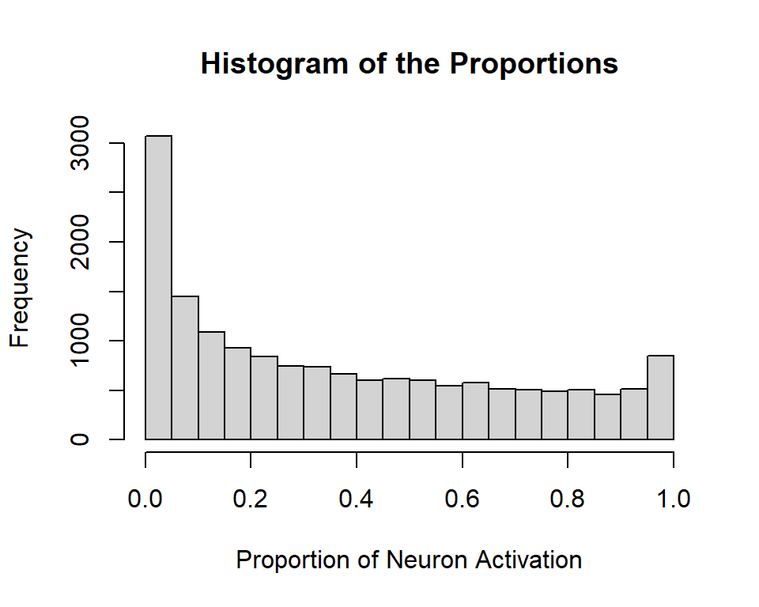

**Figure 2**. Proportion of non zero neuron activation per neuron.

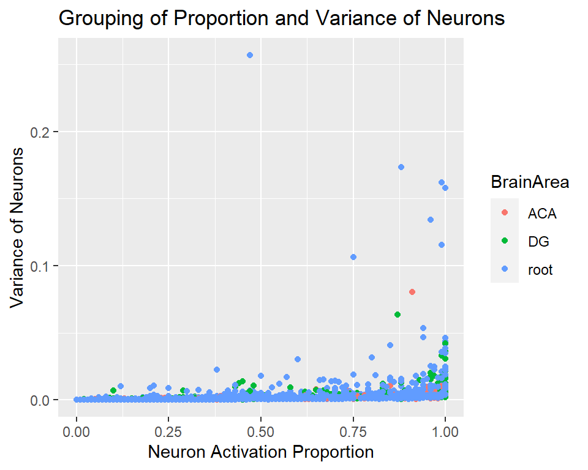

**Figure 3**. Grouping of Brain area of Activation Proportion and Variance of Neurons .

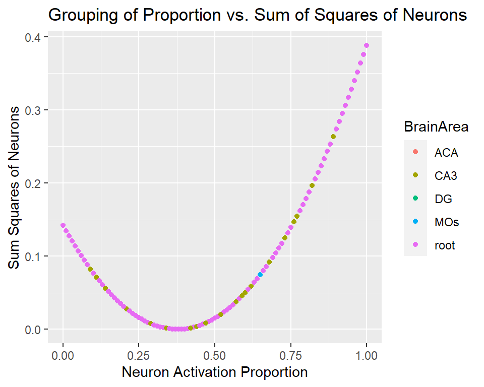

**Figure 4**. Grouping of Proportions vs. Sum of Squares of Proportions .

## 0.5 Predictive modeling

Part 3 (15 points). Model training and prediction. Finally, we will build a prediction model to predict the outcome (i.e., feedback types). The performance will be evaluated on two test sets of 100 trials randomly selected from Session 1 and Session 18, respectively. The test sets will be released on the day of submission when you need to evaluate the performance of your model.

Using method like logistic regression, SVM, etc for prediction.

## 0.6 Prediction performance on the test sets

Review: Confusion Matrix: A confusion matrix provides a tabular summary of classifier predictions compared to actual class labels. It includes true positives, true negatives, false positives, and false negatives. From the confusion matrix, various performance metrics can be derived, such as accuracy, precision, recall, and F1-score.

Precision: Precision measures the proportion of correctly predicted positive instances out of all instances predicted as positive. It quantifies the classifier’s ability to avoid false positives.

Recall: Recall (also known as sensitivity or true positive rate) calculates the proportion of correctly predicted positive instances out of all actual positive instances. It represents the classifier’s ability to identify all positive cases.

F1-score: The F1-score combines precision and recall into a single metric. It provides a balanced measure of a classifier’s performance by considering both false positives and false negatives.

```r
#Format Data
selected.vars <- c("feed","conL","conR", "neuron.activation.prop", "spk.avg","average.of.neurons","variance.of.neurons")
data.for.pca <- big.data.frame %>%
  select(all_of(selected.vars)) %>%
  na.omit()

#Perform PCA
pca.result <- prcomp(data.for.pca, scale = TRUE)

# Print the summary of the PCA
summary(pca.result)
```

```
## Importance of components:
##                           PC1    PC2    PC3    PC4    PC5     PC6     PC7
## Standard deviation     1.4812 1.0964 1.0273 0.9762 0.8874 0.80636 0.39722
## Proportion of Variance 0.3134 0.1717 0.1508 0.1361 0.1125 0.09289 0.02254
## Cumulative Proportion  0.3134 0.4852 0.6359 0.7721 0.8846 0.97746 1.00000
```

```r
# Access the principal components
pca.result$rotation  # Loadings (correlations between variables and PCs)
```

```
##                                 PC1        PC2         PC3         PC4
## feed                   -0.004839109 0.40783945 -0.49918319  0.68146897
## conL                    0.000149274 0.06964976 -0.71683718 -0.66490352
## conR                    0.035008373 0.56933701  0.48499723 -0.28818868
## neuron.activation.prop -0.513679981 0.01871927 -0.00582742 -0.03159726
## spk.avg                 0.049721268 0.70827823 -0.03351479 -0.09462673
## average.of.neurons     -0.641085281 0.03255458  0.01742799 -0.01642150
## variance.of.neurons    -0.566940305 0.04003755  0.01665390  0.01511187
##                                PC5         PC6           PC7
## feed                    0.34592461 -0.01510975  0.0129463470
## conL                    0.19109179 -0.05176513 -0.0009780847
## conR                    0.59454462 -0.05357826 -0.0009073581
## neuron.activation.prop  0.07163235  0.78121636 -0.3454271612
## spk.avg                -0.69299079  0.07452384 -0.0015008572
## average.of.neurons     -0.02202291 -0.08414466  0.7614533008
## variance.of.neurons    -0.06696530 -0.60933432 -0.5483587389
```

```r
pca.result$x  # PC scores (transformed data)
```

[output not shown]

[output cut: 10149 more lines]

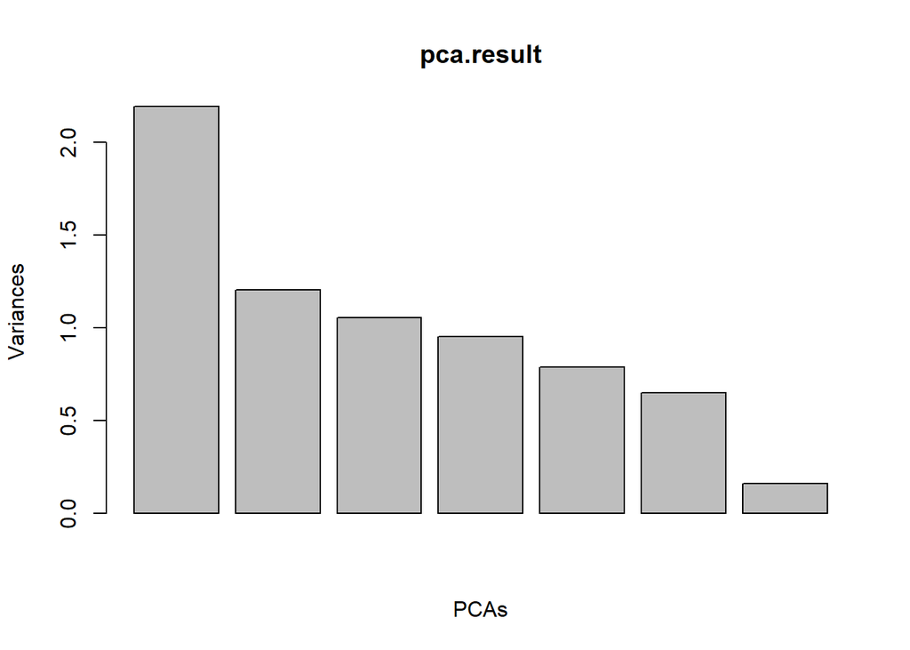

```r
# Explained variance
variance.explained <- pca.result$sdev^2 / sum(pca.result$sdev^2)
cumulative.variance <- cumsum(variance.explained)

# Plot the scree plot
#scree.plot <- ggplot(data.frame(PC = 1:length(variance.explained),
#                                VarianceExplained = variance.explained),
#                     aes(x = PC, y = VarianceExplained)) +
#  geom_bar(stat = "identity", fill = "steelblue") +
#  geom_line(aes(x = PC, y = cumulative.variance), color = "red", size = 1) +
#  labs(x = "Principal Components", y = "Variance Explained") +
#  theme_minimal()
#print(scree_plot)

plot(pca.result, xlab = "PCAs")
```

```r
#plot(pca.result, type = "1")
```

```r
misclassification <- (1- (sum(diag(confusion.matrix))/(sum(confusion.matrix))))

cat("Misclassification Error:", misclassification, "\n")
```

```
## Misclassification Error: 0.7560976
```

> > My misclassification error seems pretty high so that indicates that my prediction model does not predict for feedback type very well.

```r
#Now let's calculate the accuracy
accuracy <- sum(diag(confusion.matrix)) / sum(confusion.matrix)
print(accuracy)
```

```
## [1] 0.2439024
```

## Reference

Steinmetz, N.A., Zatka-Haas, P., Carandini, M. et al. Distributed coding of choice, action and engagement across the mouse brain. Nature 576, 266–273 (2019). https://doi.org/10.1038/s41586-019-1787-x

OpenAI. “ChatGPT: Large-scale Language Model for Conversational AI.” Version 3.5 (2021). Retrieved from https://openai.com

## Other

**This category is for extra codes and other interesting things I found in the project, but was unable to utilize or couldn’t utilize.**

PCA time

```
## Importance of components:
##                           PC1    PC2     PC3
## Standard deviation     1.4630 0.8098 0.45158
## Proportion of Variance 0.7135 0.2186 0.06798
## Cumulative Proportion  0.7135 0.9320 1.00000
```

```
##                              PC1         PC2        PC3
## neuron.activation.prop 0.5357284  0.72930914  0.4255622
## average.of.neurons     0.6410782 -0.02329006 -0.7671221
## variance.of.neurons    0.5495578 -0.68378779  0.4800213
```

[output not shown]

[output cut: 16291 more lines]

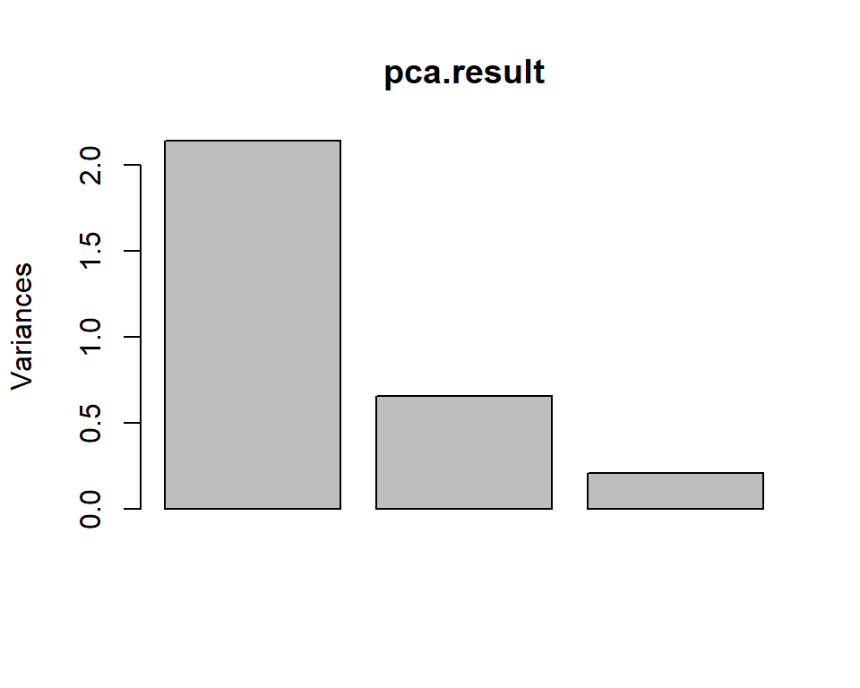

```r
# Example of a confusion matrix with two columns
predicted <- c("A", "B", "A", "B", "B")  # Predicted values
actual <- c("A", "A", "B", "B", "A")  # True labels

# Create the confusion matrix
confusion_matrix <- table(True = actual, Predicted = predicted)

# Print the confusion matrix
print(confusion_matrix)
```

```
##     Predicted
## True A B
##    A 1 2
##    B 1 1
```

## Appendix

```r
knitr::opts_chunk$set(fig.pos = 'H')
#install.packages("htmlwidgets")
#library(htmlwidgets)
suppressWarnings(library(tidyverse))
suppressWarnings(library(data.table))
suppressWarnings(library(dplyr))
suppressWarnings(library(reshape2))
suppressWarnings(library(gridExtra))
library(stats)
library(nnet)
setwd("C:/Users/ultim/Downloads/STA 141A/sessions")
session=list()
for(i in 1:18){
  session[[i]]=readRDS(paste('session',i,'.rds',sep=''))
}
sessions <- session
# Summarize the information across sessions:
# Knowing what summary we want to report, we can create a tibble:
# All values in this function serve only as place holders
library(tidyverse)
library(magrittr)
library(knitr)
library(dplyr)
n.session=length(session)

# in library tidyverse

meta <- tibble(
  mouse_name = rep('name',n.session),
  date_exp =rep('dt',n.session),
  n_brain_area = rep(0,n.session),
  n_neurons = rep(0,n.session),
  n_trials = rep(0,n.session),
  success_rate = rep(0,n.session)
)


for(i in 1:n.session){
  tmp = session[[i]];
  meta[i,1]=tmp$mouse_name;
  meta[i,2]=tmp$date_exp;
  meta[i,3]=length(unique(tmp$brain_area));
  meta[i,4]=dim(tmp$spks[[1]])[1];
  meta[i,5]=length(tmp$feedback_type);
  meta[i,6]=mean(tmp$feedback_type+1)/2;
}
kable(meta, format = "html", table.attr = "class='table table-striped'",digits=2)
i.s=2 # indicator for this session

i.t=1 # indicator for this trial

spk.trial = session[[i.s]]$spks[[i.t]]
area=session[[i.s]]$brain_area

# We need to first calculate the number of spikes for each neuron during this trial
spk.count=apply(spk.trial,1,sum)

# for(i in 1:dim(spk.trial)[1]){
#  spk.count[i]=sum(spk.trial[i,])
# }

# Next we take the average of spikes across neurons that live in the same area

# You can use tapply() or group_by() in dplyr

# tapply():
spk.average.tapply=tapply(spk.count, area, mean)


# dplyr:
# To use dplyr you need to create a data frame
tmp <- data.frame(
  area = area,
  spikes = spk.count
)
# Calculate the average by group using dplyr
spk.average.dplyr =tmp %>%
  group_by(area) %>%
  summarize(mean= mean(spikes))

# Wrapping up the function:

average_spike_area<-function(i.t,this_session){
  spk.trial = this_session$spks[[i.t]]
  area= this_session$brain_area
  spk.count=apply(spk.trial,1,sum)
  spk.average.tapply=tapply(spk.count, area, mean)
  return(spk.average.tapply)
  }

# Test the function
average_spike_area(1,this_session = session[[i.s]])

n.trial=length(session[[i.s]]$feedback_type)
n.area=length(unique(session[[i.s]]$brain_area ))
# Alternatively, you can extract these information in the meta that we created before.

# We will create a data frame that contain the average spike counts for each area, feedback type,  the two contrasts, and the trial id

trial.summary =matrix(nrow=n.trial,ncol= n.area+1+2+1)
for(i.t in 1:n.trial){
  trial.summary[i.t,]=c(average_spike_area(i.t,this_session = session[[i.s]]),
                          session[[i.s]]$feedback_type[i.t],
                        session[[i.s]]$contrast_left[i.t],
                        session[[i.s]]$contrast_right[i.s],
                        i.t)
}

colnames(trial.summary)=c(names(average_spike_area(i.t,this_session = session[[i.s]])), 'feedback', 'left contr.','right contr.','id' )

# Turning it into a data frame
trial.summary <- as_tibble(trial.summary)
area.col=rainbow(n=n.area,alpha=0.7)
# In base R, I usually initiate a blank plot before drawing anything on it
plot(x=1,y=0, col='white',xlim=c(0,n.trial),ylim=c(0.5,2.2), xlab="Trials",ylab="Average spike counts", main=paste("Spikes per area in Session", i.s))


for(i in 1:n.area){
  lines(y=trial.summary[[i]],x=trial.summary$id,col=area.col[i],lty=2,lwd=1)
  lines(smooth.spline(trial.summary$id, trial.summary[[i]]),col=area.col[i],lwd=3)
  }
legend("topright",
  legend = colnames(trial.summary)[1:n.area],
  col = area.col,
  lty = 1,
  cex = 0.8
)
#This function is designed to extract the neurons from each session
#takes forever to run
neuron.extract <- function(fdbk){
  sum.list <- list()
  for (i in 1:18){
    #Incorporate feedback
    feed <- session[[i]][["feedback_type"]]
    #Incorporate spikes
    spks <- session[[i]][["spks"]]
    #Incorporate Trials
    trial <- 1:length(feed)
    tmp.feed <- data.frame(feed,trial)
    feedFilter <- tmp.feed %>% filter(feed %in% c(fdbk))
    data.list <- list()
    tempVec <- c()
    brain.vec <- c(matrix(0,dim(spks[[1]])[1],1))
      for (r in 1:dim(spks[[1]])[1]){
       data.list[[r]] <-  rowSums(spks[[1]])[r]/40
      }
  for (j in 2:length(spks)){
    for (w in 1:dim(spks[[1]])[1]){
      brain.vec <- rowSums(spks[[j]])[w]/40
      data.list[[w]] <- c(data.list[[w]], brain.vec)
    }
  }
sum.list[[i]] <- data.list
}
return(sum.list) }
neuron.extract.vals <- neuron.extract(c(1,-1))
BrainArea <- c()

n.session <- length(session)
for(i in 1:n.session){
  for(j in 1:length(session[[i]]$brain_area)){
    BrainArea <- c(BrainArea,session[[i]]$brain_area[[j]])
  }
}
length(BrainArea)
#Find all non-zero values of neuron.extract.vals for the first neuron
hist(neuron.extract.vals[[1]][[1]], main = "Histogram of First Neuron Activation")
placeholder <- !(neuron.extract.vals[[1]][[1]]==0)
neuron.activity <- neuron.extract.vals[[1]][[1]][placeholder]
#neuron.extract.vals[[1]][[1]][neuron.extract.vals[[1]][[1]]!=0]

#Want the proportion of activation rates of each neuron
neuron.activation.prop <- c()
for(i in 1:length(neuron.extract.vals)){
  for(j in 1:length(neuron.extract.vals[[i]])){
    temp = round(sum(!(neuron.extract.vals[[i]][[j]]==0))/length(neuron.extract.vals[[i]][[j]]),digits = 2)
    neuron.activation.prop = c(neuron.activation.prop,temp)
  }
}
#cluster by responsiveness
#just take avg of spk count of clusters
#spk count over time, used time
#explain why we want more coeff
#Finding the variance of the activation proportions
variance.of.neurons <- c()
for(i in 1:length(neuron.extract.vals)){
  for(j in 1:length(neuron.extract.vals[[i]])){
    variance.of.neurons = c(variance.of.neurons, var(neuron.extract.vals[[i]][[j]]))
  }
}
```

```r
#Finding the average of the activation proportions
average.of.neurons <- c()
for(i in 1:length(neuron.extract.vals)){
  for(j in 1:length(neuron.extract.vals[[i]])){
    average.of.neurons <- c(average.of.neurons, mean(neuron.extract.vals[[i]][[j]]))
  }
}

#All of the brain areas are in the vector
length(BrainArea)
length(neuron.activation.prop)

name.brain.areas <- unique(BrainArea)
indexVec <- c(1:length(neuron.activation.prop))
brain.area.neuron.prop <- data.frame(BrainArea, neuron.activation.prop,indexVec)

#ggplot(x = brain.area.neuron.prop$indexVec, y = brain.area.neuron.prop$neuron.activation.prop ,data = brain.area.neuron.prop,
#       color = as.factor(BrainArea)) +
#       labs(x ="Index of the Length of Average Proportions" ,
#               y = "Average Neuron Activation Proportion",
#              title = "Index vs. Average Neuron Activation Proportion")+
#  geom_point(mapping = aes(x = brain.area.neuron.prop$indexVec, y = brain.area.neuron.prop$neuron.activation.prop))


#Want to create a structure to contain the brain areas with their average activation proportion



#Function to help compare the unique brain areas to where
compare.brain.areas <- function(vector1,vector2){
  comparison <- vector1 %in% vector2
  return(any(comparison))
}
#Want to show which brain area is used what session
unique.brain.area.len <-length(name.brain.areas)
brain.area.per.session <- matrix(, nrow = n.session, ncol =unique.brain.area.len)
colnames(brain.area.per.session) <- name.brain.areas
rownames(brain.area.per.session) <- c(1:18)

#Want to compare what the unique names to all the brain ares
for(i in 1:n.session){
  tempVal <- c(session[[i]]$brain_area)
  for(j in 1:unique.brain.area.len){
    brain.area.per.session[i,j] = compare.brain.areas(tempVal,name.brain.areas[j])
  }
}
head(brain.area.per.session)
#Want to show how many sessions use a given brain area
n.brain.areas.used<- c()
for(i in 1:unique.brain.area.len){
  n.brain.areas.used <- c(n.brain.areas.used, sum(brain.area.per.session[,i]))
}

brain.areas.used <- data.frame(name.brain.areas,n.brain.areas.used)
head(brain.areas.used)
#This is average spikes throughout all trials
spk.avg <- c()
for (i in 1:18) {
    length.trial = length(session[[i]]$spks)
  for (k in 1:length.trial) {
    spk.per = session[[i]]$spks[[k]]
    num.spk = apply(spk.per, 1, sum)
    spk.avg = c(spk.avg, mean(num.spk))
  }
}
#Want the proportion of activation rates of each neuron
neuron.activation.prop <- c()
for(i in 1:length(neuron.extract.vals)){
  for(j in 1:length(neuron.extract.vals[[i]])){
    temp = round(sum(!(neuron.extract.vals[[i]][[j]]==0))/length(neuron.extract.vals[[i]][[j]]),digits = 2)
    neuron.activation.prop = c(neuron.activation.prop,temp)
  }
}
#cluster by responsiveness
#just take avg of spk count of clusters
#spk count over time, used time
#explain why we want more coeff
#Finding the variance of the activation proportions
#Want the proportion of activation rates of each neuron
neuron.activation.prop <- c()
for(i in 1:length(neuron.extract.vals)){
  for(j in 1:length(neuron.extract.vals[[i]])){
    temp = round(sum(!(neuron.extract.vals[[i]][[j]]==0))/length(neuron.extract.vals[[i]][[j]]),digits = 2)
    neuron.activation.prop = c(neuron.activation.prop,temp)
  }
}
variance.of.neurons <- c()
for(i in 1:length(neuron.extract.vals)){
  for(j in 1:length(neuron.extract.vals[[i]])){
    variance.of.neurons = c(variance.of.neurons, var(neuron.extract.vals[[i]][[j]]))
  }
}

#Finding the average of the activation proportions
average.of.neurons <- c()
for(i in 1:length(neuron.extract.vals)){
  for(j in 1:length(neuron.extract.vals[[i]])){
    average.of.neurons <- c(average.of.neurons, mean(neuron.extract.vals[[i]][[j]]))
  }
}

#Visualize the frequency of proportions
hist(neuron.activation.prop, main = "Histogram of the Proportions", xlab = "Proportion of Neuron Activation")


successes <- c()
failures <-c()
activation.totals <- data.frame(successes,failures)
for(i in 1:length(neuron.extract.vals)){
  for(j in 1:length(neuron.extract.vals[[i]])){
    temp = data.frame(round(sum((neuron.extract.vals[[i]][[j]]==0))/length(neuron.extract.vals[[i]][[j]]),digits = 2),
                      round(sum(!(neuron.extract.vals[[i]][[j]]==0))/length(neuron.extract.vals[[i]][[j]]),digits = 2))
    activation.totals = rbind(temp)
  }
}
n.neuron <- c(1:length(BrainArea))
#Make data frames with brain area and average activation
brain.area.and.neuron <- data.frame(BrainArea, neuron.activation.prop, average.of.neurons, variance.of.neurons)
#Now, we want grab a few brain areas, CA1, root, DG
Most.Frequent.Brain.Area <- brain.area.and.neuron %>% filter(BrainArea == "ACA" | BrainArea == "root" | BrainArea == "DG")

#plot the 3 groups
Most.Frequent.Brain.Area %>% ggplot(aes(x = neuron.activation.prop, y = variance.of.neurons , color = BrainArea)) +
  geom_point()+
  labs(title = "Grouping of Proportion and Variance of Neurons",
       x = "Neuron Activation Proportion", y = "Variance of Neurons")
#Now, we want grab a few brain areas, CA1, root, DG, MOs, VISp, and CA3
Most.Frequent.Brain.Area <- brain.area.and.neuron %>%
  filter(BrainArea == "ACA" | BrainArea == "root" | BrainArea == "DG" | BrainArea == "MOs" | BrainArea == "Visp" | BrainArea == "CA3") %>%
  mutate(new.brain.prop = ((neuron.activation.prop - mean(neuron.activation.prop))^2))
#plot the 3 groups
Most.Frequent.Brain.Area %>% ggplot(aes(x = neuron.activation.prop, y = new.brain.prop, color = BrainArea)) +
  geom_point()+
  labs(title = "Grouping of Proportion vs. Sum of Squares of Neurons",
       x = "Neuron Activation Proportion", y = "Sum Squares of Neurons")
#Read in test data
setwd("C:/Users/ultim/Downloads/STA 141A/test")
test.data <- list()
for(i in 1:2){
  test.data[[i]] = readRDS(paste('./test',i,'.rds',sep=''))
}

#gathering data of feedback type, contrast left, and contrast right
feed <- c()
conL <- c()
conR <- c()


for (i in 1:length(session)){

  conL <- append(conL, session[[i]][["contrast_left"]])
  conR <- append(conR, session[[i]][["contrast_right"]])
  feed <- append(feed, session[[i]][["feedback_type"]] == 1)
```

```r
}
big.data.frame <- data.frame(feed, conL, conR)

len.difference <- length(neuron.activation.prop) - dim(big.data.frame)[1]
feed <- c(feed, rep(NA, len.difference))
conL <- c(conL, rep(NA, len.difference))
conR <- c(conR, rep(NA, len.difference))

len.difference2 <- length(neuron.activation.prop) - length(spk.avg)
spk.avg <- c(spk.avg, rep(NA, len.difference2))

len.difference3 <- length(neuron.activation.prop) - length(average.of.neurons)
average.of.neurons <- c(average.of.neurons, rep(NA, len.difference3))
variance.of.neurons <- c(variance.of.neurons, rep(NA, len.difference3))

big.data.frame <- data.frame(feed, conL, conR, neuron.activation.prop, spk.avg,average.of.neurons,variance.of.neurons)


#Might need to take samples to effectively use test data

#Format Data
selected.vars <- c("feed","conL","conR", "neuron.activation.prop", "spk.avg","average.of.neurons","variance.of.neurons")
data.for.pca <- big.data.frame %>%
  select(all_of(selected.vars)) %>%
  na.omit()

#Perform PCA
pca.result <- prcomp(data.for.pca, scale = TRUE)

# Print the summary of the PCA
summary(pca.result)

# Access the principal components
pca.result$rotation  # Loadings (correlations between variables and PCs)
pca.result$x  # PC scores (transformed data)

# Explained variance
variance.explained <- pca.result$sdev^2 / sum(pca.result$sdev^2)
cumulative.variance <- cumsum(variance.explained)

# Plot the scree plot
#scree.plot <- ggplot(data.frame(PC = 1:length(variance.explained),
#                                VarianceExplained = variance.explained),
#                     aes(x = PC, y = VarianceExplained)) +
#  geom_bar(stat = "identity", fill = "steelblue") +
#  geom_line(aes(x = PC, y = cumulative.variance), color = "red", size = 1) +
#  labs(x = "Principal Components", y = "Variance Explained") +
#  theme_minimal()
#print(scree_plot)

plot(pca.result, xlab = "PCAs")
#plot(pca.result, type = "1")
# Extract the principal components
pc.scores <- as.data.frame(pca.result$x)  # Principal component scores

# Assuming your response variable is called "response" and there are other predictors

# Combine the response variable and principal components
#Need to amend rows again
#PC1 <- c(pc.scores[1])
#PC2 <- c(pc.scores[2])
#PC3 <- c(pc.scores[3])
#PC4 <- c(pc.scores[4])
#PC5 <- c(pc.scores[5])
#PC6 <- c(pc.scores[6])
#data.pca <- data.frame(PC1,PC2,PC3,PC4)
#quick.sample <- sample(big.data.frame$feed,length(data.pca[1]))
#data.pca <- cbind(quick.sample,data.pca)
#test.df <- data.frame(test.data$feed)


# Fit multinomial regression
#model <- glm(big.data.frame$feed~ mean(PC1) + mean(PC2) +mean(PC3) +mean(PC4) +mean(PC5)+mean(PC6))

#library(nnet)
#model <- multinom(quick.sample ~ data.pca[[1]] +  data.pca[2] + data.pca[3] , data = data.pca)
#summary(model)  # View model summary


#Creating a glm of contrast left + contrast right vs feedback type
big.data.glm <- glm(big.data.frame$feed~big.data.frame$conL+big.data.frame$conR + big.data.frame$neuron.activation.prop + big.data.frame$spk.avg,
                    data = big.data.frame,
                    family = "binomial")

#Obtain Estimates and their Standard Errors
parameter.estimates <- summary(big.data.glm)$coef[,1:2]
cat("Parameter Estimates and Standard Errors:\n")
print(parameter.estimates)

#Extract the Predictor Variable from the Test Data
test.feedback <- data.frame()

#Predict the feedback using test data
prediction <- predict(big.data.glm, newdata = data.frame(test.data[[1]]$feedback_type), type = "response")

#make them binary for the confusion matrix
predict.binary <- ifelse(prediction > 0.5,"-1","1")

predict.binary.sample <- sample(predict.binary, 100)

#create confusion matrix
confusion.matrix <- table(Actual = test.data[[1]]$feedback_type, Predicted = predict.binary.sample)

#print confusion matrix
print(confusion.matrix)
misclassification <- (1- (sum(diag(confusion.matrix))/(sum(confusion.matrix))))

cat("Misclassification Error:", misclassification, "\n")
#Now let's calculate the accuracy
accuracy <- sum(diag(confusion.matrix)) / sum(confusion.matrix)
print(accuracy)

sessionInfo()
#All of the brain areas are in the vector
length(BrainArea)
length(neuron.activation.prop)

name.brain.areas <- unique(BrainArea)
indexVec <- c(1:length(neuron.activation.prop))
brain.area.neuron.prop <- data.frame(BrainArea, neuron.activation.prop,indexVec)

ggplot(x = brain.area.neuron.prop$indexVec, y = brain.area.neuron.prop$neuron.activation.prop ,data = brain.area.neuron.prop,
       color = as.factor(BrainArea)) +
       labs(x ="Index of the Length of Average Proportions" ,
               y = "Average Neuron Activation Proportion",
              title = "Index vs. Average Neuron Activation Proportion")+
  geom_point(mapping = aes(x = brain.area.neuron.prop$indexVec, y = brain.area.neuron.prop$neuron.activation.prop))


#Want to create a structure to contain the brain areas with their average activation proportion
#Testing if I can get a specific sessions brain areas
session.1.brain.area <-c()
n.sessions <- length(sessions)
for(i in 1:length(n.sessions)){
  for(j in 1:length(session[[i]]$brain_area))
    session.1.brain.area <-c(session.1.brain.area,session[[i]]$brain_area[[j]])
}

#Function to help compare the unique brain areas to where
compare.brain.areas <- function(vector1,vector2){
  comparison <- vector1 %in% vector2
  return(any(comparison))
}

compare.brain.areas(session.1.brain.area,name.brain.areas[1])

#finds the densities of all neurons in each trial, also takes a while
#Actually want non zero neurons because the 0 ones aren't helpful
#allDenList <- list()
#listCount <- list()
#for (i in 1:18){
#  for (j in 1:length(neuron.extract.vals[[i]])){
#        allDenList[[listCount]] <- density(!neuron.extract.vals[[i]][[j]]==0)
#        listCount = listCount + 1
#        }
#  }
#Let's sample all the densities
#set.seed(1)
#densitySubset <- sample(allDenList, size = 100, replace = FALSE)
#length(densitySubset)
#Need to turn my samples into data frames for ggplot
#densityX <- c()
#densityY <- c()
#for(i in 1:length(densitySubset)){
 # densityX <- c(densityX,densitySubset[[i]]$x)
#  densityY <- c(densityY,densitySubset[[i]]$y)
#}
#densitySample <- data.frame(densityX,densityY)
```

```r
#Try to plot the densities to see what they look like
#plot(densitySubset[[1]], main = "Density Function of Sample 1")
#plot(densitySubset[[2]], main = "Density Function of Sample 2")
#plot(x = densitySample$densityX, y = densitySample$densityY, main = "Plot of X density vs Y density")
#ggplot(x = densitySample$densityX, y = densitySample$densityY, data = densitySample)+
#  geom_point(mapping = aes(x = densitySample$densityX, y = densitySample$densityY))+
#  xlim(-.05,.05)
#  geom_point(mapping = aes(densitySample[[1]]))
#get rid of 0s
#proportion of 0s,want to comment on this
#average neuron activity for each mouse used in the test data
cori.feedback <- c()
cori.conL <- c()
cori.conR <- c()
for(i in 1:3){
  for(j in 1:length(session[[i]]$feedback_type)){
    cori.feedback = c(cori.feedback, session[[i]]$feedback_type[[j]])
    cori.conL <- c(cori.conL,session[[i]]$contrast_left[[j]])
    cori.conR <- c(cori.conR,session[[i]]$contrast_right[[j]])
  }
}

forssmann.conL <- c()
forssmann.conR <- c()
forssmann.feedback <- c()
for(i in 4:7) {
  for(j in 1:length(session[[i]]$feedback_type)){
    forssmann.feedback = c(forssmann.feedback,session[[i]]$feedback_type[[j]])
    forssmann.conL <- c(forssmann.conL,session[[i]]$contrast_left[[j]])
    forssmann.conR <- c(forssmann.conR,session[[i]]$contrast_right[[j]])
  }
}

hench.conL <- c()
hench.conR <- c()
hench.feedback <- c()
for(i in 8:11){
  for(j in 1:length(session[[i]]$feedback_type)){
    hench.feedback = c(hench.feedback, session[[i]]$feedback_type[[j]])
    hench.conL <- c(hench.conL,session[[i]]$contrast_left[[j]])
    hench.conR <- c(hench.conR,session[[i]]$contrast_right[[j]])
  }
}

lederberg.conL <- c()
lederberg.conR <- c()
lederberg.feedback <- c()
for(i in 12:18){
  for(j in 1:length(session[[i]]$feedback_type)){
    lederberg.feedback = c(lederberg.feedback, session[[i]]$feedback_type[[j]])
    lederberg.conL <- c(lederberg.conL,session[[i]]$contrast_left[[j]])
    lederberg.conR <- c(lederberg.conR,session[[i]]$contrast_right[[j]])
  }
}

#Making the differences in lengths 0
difference.trials1 <- length(lederberg.feedback)-length(cori.feedback)
cori.feedback <- c(cori.feedback,rep.int(NA, times = difference.trials1))
cori.conL <- c(cori.conL,rep.int(NA, times = difference.trials1))
cori.conR <- c(cori.conR,rep.int(NA, times = difference.trials1))
difference.trials2 <- length(lederberg.feedback)-length(forssmann.feedback)
forssmann.feedback <- c(forssmann.feedback,rep.int(NA, times = difference.trials2))
forssmann.conL <- c(forssmann.conL,rep.int(NA, times = difference.trials2))
forssmann.conR <- c(forssmann.conR,rep.int(NA, times = difference.trials2))
difference.trials3 <- length(lederberg.feedback)-length(hench.feedback)
hench.feedback <- c(hench.feedback,rep.int(NA, times = difference.trials3))
hench.conL <- c(hench.conL,rep.int(NA, times = difference.trials3))
hench.conR <- c(hench.conR,rep.int(NA, times = difference.trials3))

test.mouse.feedback <- data.frame(cori.feedback,forssmann.feedback,hench.feedback,lederberg.feedback,
                                  cori.conL,forssmann.conL,hench.conL,lederberg.conL,
                                  cori.conR,forssmann.conR,hench.conR,lederberg.conR)
#Mouse Feedback histograms
#is valid, just how to use, ability of mouse to do task, may be inaccurate due to too many trials.
mouse.length <- length(cori.feedback)

#hist(cori.feedback, main = "Histogram of Cori's Feedback", xlab = "Cori's Feedback")
for(i in 1:4){
  mouse.names <- c("Cori's Feedback", "Forssmann's Feedback", "Hench's Feedback", "Lederberg's Feedback")
  hist(test.mouse.feedback[[i]], main = mouse.names[i], xlab = mouse.names[i])
  mouse.table <-table(test.mouse.feedback[[i]])
  barplot(mouse.table, main = mouse.names[i])
}
#Format Data
selected.vars <- c("neuron.activation.prop", "average.of.neurons", "variance.of.neurons")
data.for.pca <- brain.area.and.neuron %>%
  select(all_of(selected.vars)) %>%
  na.omit()

#Perform PCA
pca.result <- prcomp(data.for.pca, scale = TRUE)

# Print the summary of the PCA
summary(pca.result)

# Access the principal components
pca.result$rotation  # Loadings (correlations between variables and PCs)
pca.result$x  # PC scores (transformed data)

# Explained variance
variance.explained <- pca.result$sdev^2 / sum(pca.result$sdev^2)
cumulative.variance <- cumsum(variance.explained)

# Plot the scree plot
#scree.plot <- ggplot(data.frame(PC = 1:length(variance.explained),
#                                VarianceExplained = variance.explained),
#                     aes(x = PC, y = VarianceExplained)) +
#  geom_bar(stat = "identity", fill = "steelblue") +
#  geom_line(aes(x = PC, y = cumulative.variance), color = "red", size = 1) +
#  labs(x = "Principal Components", y = "Variance Explained") +
#  theme_minimal()
#print(scree_plot)

plot(pca.result)
# Example of a confusion matrix with two columns
predicted <- c("A", "B", "A", "B", "B")  # Predicted values
actual <- c("A", "A", "B", "B", "A")  # True labels

# Create the confusion matrix
confusion_matrix <- table(True = actual, Predicted = predicted)

# Print the confusion matrix
print(confusion_matrix)
```